# GRANITUS hypothesis testing

# ERP EXPERIMENT: EEG SIGNAL (HYPOTHESES 4-6)

## 1. HYPOTHESES

### Hypothesis 4

Brain responses (N400, P600) to well-formed sentences will differ between native-accented and foreign-accented speech (“grammatical tinnitus”).

### Hypothesis 5

Sentences with grammatical errors will elicit reduced brain responses (N400, P600) in foreign-accented speech in comparison to native-accented speech.

### Hypothesis 6

Sentences with phonetic errors will elicit reduced brain responses (PMN, N400, P600) in foreign-accented speech in comparison to native-accented speech.

## 2. VARIABLES

**SENTENCE_TYPE** The type of manipulation applied to the sentence. Values: well-formed/grammatical/phonetic.

**SENTENCE_ACCENT** Accent of the speaker producing the presented sentence.

**ERP_MEAN_AMPLITUDE** Mean of all voltages recorded at the given channel in the specified time-window.

**ERP_RESPONSE_GRAM** Response accuracy to the grammaticality question. Values: correct, incorrect.

**ERP_ROI** Region of interest. A group of channels representing major scalp areas.

Current ROI values:

- frontal {‘F3’, ‘Fz’, ‘F4’ }
- central {‘C3’, ‘Cz’, ‘C4’}
- parietal {‘P3’, ‘Pz’, ‘P4’}

## 3. DESCRIPTIVE STATISTICS AND PLOTS

**PLOT: NATIVE (VOWEL ONSET)**

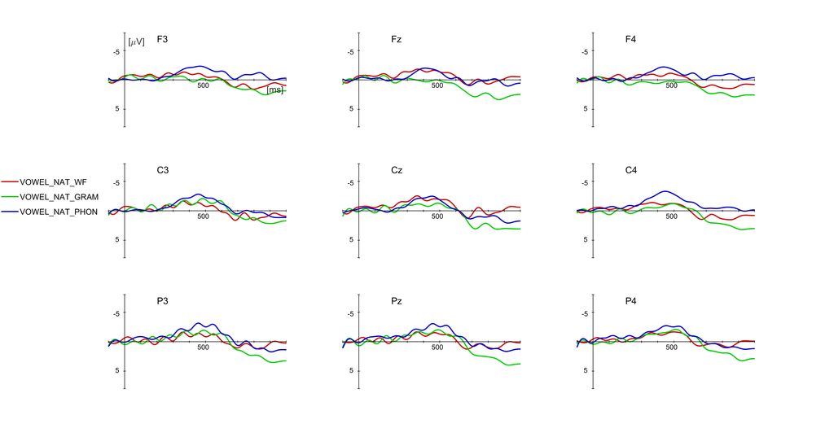

**PLOT: FOREIGN (VOWEL ONSET)**

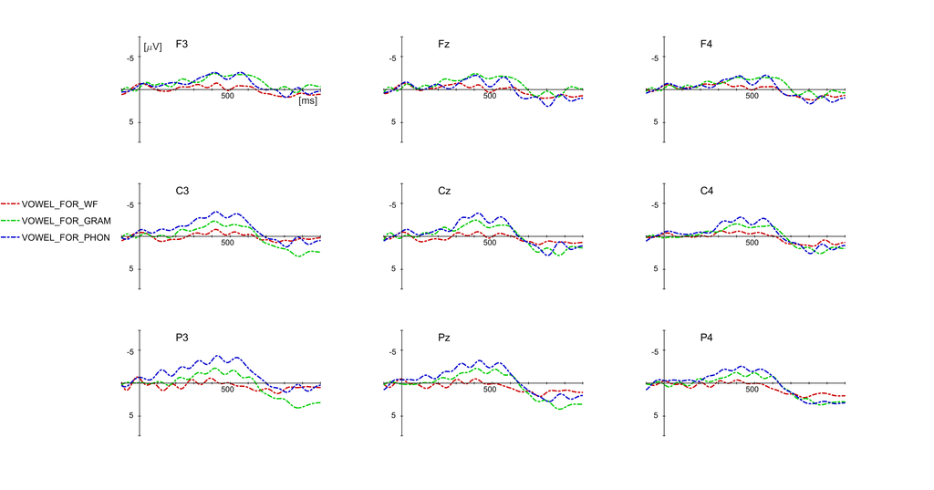

**HISTOGRAM**

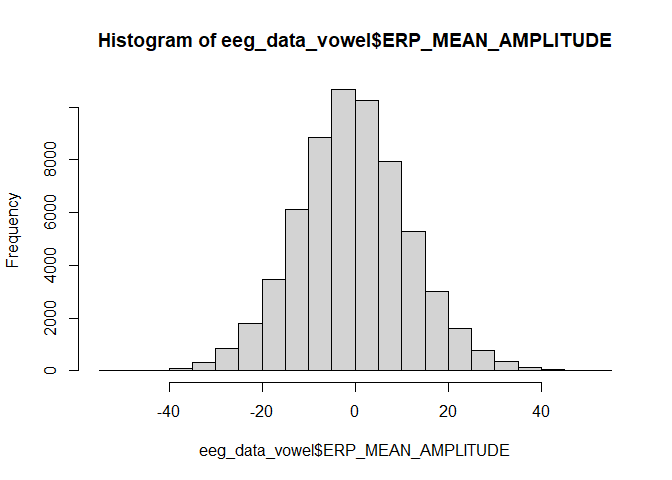

## 4. MODELS (ALL DATA)

### N400 (300-500 MS)

#### Model

```
## Linear mixed model fit by REML. t-tests use Satterthwaite's method [
## lmerModLmerTest]
## Formula: ERP_MEAN_AMPLITUDE ~ ERP_ROI * SENTENCE_ACCENT * SENTENCE_TYPE +
##     (1 + SENTENCE_ACCENT + SENTENCE_TYPE | PART_ID) + (1 | SENTENCE_ID)
##    Data: eeg_data_vowel_n400
##
## REML criterion at convergence: 227788.9
##
## Scaled residuals:
##     Min      1Q  Median      3Q     Max
## -5.0586 -0.6473 -0.0059  0.6396  5.4585
##
## Random effects:
##  Groups      Name               Variance Std.Dev. Corr
##  SENTENCE_ID (Intercept)        11.877   3.446
##  PART_ID     (Intercept)         1.987   1.410
##              SENTENCE_ACCENTFOR  2.374   1.541    -0.41
##              SENTENCE_TYPEGRAM   3.002   1.733    -0.23 -0.32
##              SENTENCE_TYPEPHON   2.242   1.497    -0.55  0.00  0.37
##  Residual                       90.415   9.509
## Number of obs: 30843, groups:  SENTENCE_ID, 540; PART_ID, 27
##
## Fixed effects:
##                                                         Estimate Std. Error
## (Intercept)                                           -6.518e-01  5.144e-01
## ERP_ROICENTRAL                                        -3.610e-01  3.278e-01
## ERP_ROIPOSTERIOR                                      -8.017e-02  3.278e-01
## SENTENCE_ACCENTFOR                                     4.958e-02  6.814e-01
## SENTENCE_TYPEGRAM                                      3.347e-01  7.007e-01
## SENTENCE_TYPEPHON                                     -8.913e-01  6.782e-01
## ERP_ROICENTRAL:SENTENCE_ACCENTFOR                      4.302e-01  4.601e-01
## ERP_ROIPOSTERIOR:SENTENCE_ACCENTFOR                    5.325e-01  4.601e-01
## ERP_ROICENTRAL:SENTENCE_TYPEGRAM                      -4.035e-01  4.634e-01
## ERP_ROIPOSTERIOR:SENTENCE_TYPEGRAM                    -8.934e-01  4.634e-01
## ERP_ROICENTRAL:SENTENCE_TYPEPHON                      -2.622e-01  4.605e-01
## ERP_ROIPOSTERIOR:SENTENCE_TYPEPHON                    -5.882e-01  4.605e-01
## SENTENCE_ACCENTFOR:SENTENCE_TYPEGRAM                  -1.082e+00  8.632e-01
## SENTENCE_ACCENTFOR:SENTENCE_TYPEPHON                  -4.095e-01  8.615e-01
## ERP_ROICENTRAL:SENTENCE_ACCENTFOR:SENTENCE_TYPEGRAM    1.803e-02  6.522e-01
## ERP_ROIPOSTERIOR:SENTENCE_ACCENTFOR:SENTENCE_TYPEGRAM -2.756e-02  6.522e-01
```

[output cut: 27 more lines]

```
## SENTENCE_TYPEPHON                                       0.1898
## ERP_ROICENTRAL:SENTENCE_ACCENTFOR                       0.3498
## ERP_ROIPOSTERIOR:SENTENCE_ACCENTFOR                     0.2472
## ERP_ROICENTRAL:SENTENCE_TYPEGRAM                        0.3838
## ERP_ROIPOSTERIOR:SENTENCE_TYPEGRAM                      0.0539 .
## ERP_ROICENTRAL:SENTENCE_TYPEPHON                        0.5692
## ERP_ROIPOSTERIOR:SENTENCE_TYPEPHON                      0.2015
## SENTENCE_ACCENTFOR:SENTENCE_TYPEGRAM                    0.2104
## SENTENCE_ACCENTFOR:SENTENCE_TYPEPHON                    0.6347
## ERP_ROICENTRAL:SENTENCE_ACCENTFOR:SENTENCE_TYPEGRAM     0.9779
## ERP_ROIPOSTERIOR:SENTENCE_ACCENTFOR:SENTENCE_TYPEGRAM   0.9663
## ERP_ROICENTRAL:SENTENCE_ACCENTFOR:SENTENCE_TYPEPHON     0.3001
## ERP_ROIPOSTERIOR:SENTENCE_ACCENTFOR:SENTENCE_TYPEPHON   0.4302
## ---
## Signif. codes:  0 '***' 0.001 '**' 0.01 '*' 0.05 '.' 0.1 ' ' 1
```

```
##
## Correlation matrix not shown by default, as p = 18 > 12.
## Use print(x, correlation=TRUE)  or
##     vcov(x)        if you need it
```

[output not shown]

[output not shown]

```
##  ERP_ROI   SENTENCE_ACCENT SENTENCE_TYPE emmean    SE  df asymp.LCL asymp.UCL
##  FRONTAL   NAT             WF            -0.652 0.514 Inf     -1.66   0.35639
##  CENTRAL   NAT             WF            -1.013 0.514 Inf     -2.02  -0.00458
##  POSTERIOR NAT             WF            -0.732 0.514 Inf     -1.74   0.27621
##  FRONTAL   FOR             WF            -0.602 0.535 Inf     -1.65   0.44670
##  CENTRAL   FOR             WF            -0.533 0.535 Inf     -1.58   0.51595
##  POSTERIOR FOR             WF            -0.150 0.535 Inf     -1.20   0.89904
##  FRONTAL   NAT             GRAM          -0.317 0.580 Inf     -1.45   0.81888
##  CENTRAL   NAT             GRAM          -1.081 0.580 Inf     -2.22   0.05439
##  POSTERIOR NAT             GRAM          -1.291 0.580 Inf     -2.43  -0.15465
##  FRONTAL   FOR             GRAM          -1.349 0.541 Inf     -2.41  -0.28970
##  CENTRAL   FOR             GRAM          -1.666 0.541 Inf     -2.73  -0.60595
##  POSTERIOR FOR             GRAM          -1.818 0.541 Inf     -2.88  -0.75828
##  FRONTAL   NAT             PHON          -1.543 0.509 Inf     -2.54  -0.54597
##  CENTRAL   NAT             PHON          -2.166 0.509 Inf     -3.16  -1.16911
##  POSTERIOR NAT             PHON          -2.211 0.509 Inf     -3.21  -1.21436
##  FRONTAL   FOR             PHON          -1.903 0.531 Inf     -2.94  -0.86132
##  CENTRAL   FOR             PHON          -2.767 0.531 Inf     -3.81  -1.72567
##  POSTERIOR FOR             PHON          -2.550 0.531 Inf     -3.59  -1.50829
##
## Degrees-of-freedom method: asymptotic
## Confidence level used: 0.95
```

#### Contrasts: well formed vs. errors

```
## ERP_ROI = FRONTAL, SENTENCE_ACCENT = NAT:
##  contrast    estimate    SE  df z.ratio p.value
##  WF - GRAM    -0.3347 0.701 Inf  -0.478  0.8818
##  WF - PHON     0.8913 0.678 Inf   1.314  0.3872
##  GRAM - PHON   1.2260 0.708 Inf   1.733  0.1930
##
## ERP_ROI = CENTRAL, SENTENCE_ACCENT = NAT:
##  contrast    estimate    SE  df z.ratio p.value
##  WF - GRAM     0.0688 0.701 Inf   0.098  0.9947
##  WF - PHON     1.1535 0.678 Inf   1.701  0.2049
##  GRAM - PHON   1.0847 0.708 Inf   1.533  0.2754
##
## ERP_ROI = POSTERIOR, SENTENCE_ACCENT = NAT:
##  contrast    estimate    SE  df z.ratio p.value
##  WF - GRAM     0.5586 0.701 Inf   0.797  0.7047
##  WF - PHON     1.4795 0.678 Inf   2.181  0.0744
##  GRAM - PHON   0.9209 0.708 Inf   1.302  0.3943
##
## ERP_ROI = FRONTAL, SENTENCE_ACCENT = FOR:
##  contrast    estimate    SE  df z.ratio p.value
##  WF - GRAM     0.7472 0.699 Inf   1.070  0.5329
##  WF - PHON     1.3008 0.677 Inf   1.921  0.1327
##  GRAM - PHON   0.5536 0.707 Inf   0.783  0.7132
##
## ERP_ROI = CENTRAL, SENTENCE_ACCENT = FOR:
##  contrast    estimate    SE  df z.ratio p.value
##  WF - GRAM     1.1327 0.699 Inf   1.622  0.2365
##  WF - PHON     2.2343 0.677 Inf   3.300  0.0028
##  GRAM - PHON   1.1017 0.707 Inf   1.559  0.2636
##
## ERP_ROI = POSTERIOR, SENTENCE_ACCENT = FOR:
##  contrast    estimate    SE  df z.ratio p.value
##  WF - GRAM     1.6681 0.699 Inf   2.388  0.0446
##  WF - PHON     2.4001 0.677 Inf   3.545  0.0011
##  GRAM - PHON   0.7320 0.707 Inf   1.036  0.5542
##
## Degrees-of-freedom method: asymptotic
## P value adjustment: tukey method for comparing a family of 3 estimates
```

#### Contrasts: native vs. foreign

```
## ERP_ROI = FRONTAL, SENTENCE_TYPE = WF:
##  contrast  estimate    SE  df z.ratio p.value
##  NAT - FOR  -0.0496 0.681 Inf  -0.073  0.9420
##
## ERP_ROI = CENTRAL, SENTENCE_TYPE = WF:
##  contrast  estimate    SE  df z.ratio p.value
##  NAT - FOR  -0.4798 0.681 Inf  -0.704  0.4813
##
## ERP_ROI = POSTERIOR, SENTENCE_TYPE = WF:
##  contrast  estimate    SE  df z.ratio p.value
##  NAT - FOR  -0.5821 0.681 Inf  -0.854  0.3929
##
## ERP_ROI = FRONTAL, SENTENCE_TYPE = GRAM:
##  contrast  estimate    SE  df z.ratio p.value
##  NAT - FOR   1.0324 0.682 Inf   1.514  0.1300
##
## ERP_ROI = CENTRAL, SENTENCE_TYPE = GRAM:
##  contrast  estimate    SE  df z.ratio p.value
##  NAT - FOR   0.5841 0.682 Inf   0.857  0.3917
##
## ERP_ROI = POSTERIOR, SENTENCE_TYPE = GRAM:
##  contrast  estimate    SE  df z.ratio p.value
##  NAT - FOR   0.5274 0.682 Inf   0.773  0.4393
##
## ERP_ROI = FRONTAL, SENTENCE_TYPE = PHON:
##  contrast  estimate    SE  df z.ratio p.value
##  NAT - FOR   0.3599 0.680 Inf   0.530  0.5964
##
## ERP_ROI = CENTRAL, SENTENCE_TYPE = PHON:
##  contrast  estimate    SE  df z.ratio p.value
##  NAT - FOR   0.6011 0.680 Inf   0.884  0.3764
##
## ERP_ROI = POSTERIOR, SENTENCE_TYPE = PHON:
##  contrast  estimate    SE  df z.ratio p.value
##  NAT - FOR   0.3385 0.680 Inf   0.498  0.6185
##
## Degrees-of-freedom method: asymptotic
```

### P600 (500-900 MS)

#### Model

```
## Linear mixed model fit by REML. t-tests use Satterthwaite's method [
## lmerModLmerTest]
## Formula: ERP_MEAN_AMPLITUDE ~ ERP_ROI * SENTENCE_ACCENT * SENTENCE_TYPE +
##     (1 + SENTENCE_ACCENT + SENTENCE_TYPE | PART_ID) + (1 | SENTENCE_ID)
##    Data: eeg_data_vowel_p600
##
## REML criterion at convergence: 245205.5
##
## Scaled residuals:
##     Min      1Q  Median      3Q     Max
## -4.1464 -0.6605  0.0017  0.6582  3.7043
##
## Random effects:
##  Groups      Name               Variance Std.Dev. Corr
##  SENTENCE_ID (Intercept)         21.186   4.603
##  PART_ID     (Intercept)          2.439   1.562
##              SENTENCE_ACCENTFOR   5.045   2.246   -0.39
##              SENTENCE_TYPEGRAM    6.137   2.477   -0.34 -0.42
##              SENTENCE_TYPEPHON    6.383   2.526   -0.27 -0.40  0.56
##  Residual                       159.041  12.611
## Number of obs: 30843, groups:  SENTENCE_ID, 540; PART_ID, 27
##
## Fixed effects:
##                                                         Estimate Std. Error
## (Intercept)                                            4.973e-01  6.546e-01
## ERP_ROICENTRAL                                        -1.605e-02  4.347e-01
## ERP_ROIPOSTERIOR                                       6.389e-02  4.347e-01
## SENTENCE_ACCENTFOR                                    -2.366e-01  9.251e-01
## SENTENCE_TYPEGRAM                                      6.620e-01  9.499e-01
## SENTENCE_TYPEPHON                                     -1.053e+00  9.524e-01
## ERP_ROICENTRAL:SENTENCE_ACCENTFOR                      3.012e-01  6.103e-01
## ERP_ROIPOSTERIOR:SENTENCE_ACCENTFOR                    9.248e-01  6.103e-01
## ERP_ROICENTRAL:SENTENCE_TYPEGRAM                       6.879e-02  6.145e-01
## ERP_ROIPOSTERIOR:SENTENCE_TYPEGRAM                     2.447e-01  6.145e-01
## ERP_ROICENTRAL:SENTENCE_TYPEPHON                       3.299e-01  6.108e-01
## ERP_ROIPOSTERIOR:SENTENCE_TYPEPHON                     2.837e-01  6.108e-01
## SENTENCE_ACCENTFOR:SENTENCE_TYPEGRAM                  -1.092e+00  1.150e+00
## SENTENCE_ACCENTFOR:SENTENCE_TYPEPHON                   6.595e-01  1.148e+00
## ERP_ROICENTRAL:SENTENCE_ACCENTFOR:SENTENCE_TYPEGRAM    2.583e-01  8.649e-01
## ERP_ROIPOSTERIOR:SENTENCE_ACCENTFOR:SENTENCE_TYPEGRAM -3.847e-01  8.649e-01
```

[output cut: 25 more lines]

```
## SENTENCE_ACCENTFOR                                       0.798
## SENTENCE_TYPEGRAM                                        0.487
## SENTENCE_TYPEPHON                                        0.271
## ERP_ROICENTRAL:SENTENCE_ACCENTFOR                        0.622
## ERP_ROIPOSTERIOR:SENTENCE_ACCENTFOR                      0.130
## ERP_ROICENTRAL:SENTENCE_TYPEGRAM                         0.911
## ERP_ROIPOSTERIOR:SENTENCE_TYPEGRAM                       0.691
## ERP_ROICENTRAL:SENTENCE_TYPEPHON                         0.589
## ERP_ROIPOSTERIOR:SENTENCE_TYPEPHON                       0.642
## SENTENCE_ACCENTFOR:SENTENCE_TYPEGRAM                     0.343
## SENTENCE_ACCENTFOR:SENTENCE_TYPEPHON                     0.566
## ERP_ROICENTRAL:SENTENCE_ACCENTFOR:SENTENCE_TYPEGRAM      0.765
## ERP_ROIPOSTERIOR:SENTENCE_ACCENTFOR:SENTENCE_TYPEGRAM    0.656
## ERP_ROICENTRAL:SENTENCE_ACCENTFOR:SENTENCE_TYPEPHON      0.469
## ERP_ROIPOSTERIOR:SENTENCE_ACCENTFOR:SENTENCE_TYPEPHON    0.407
```

```
##
## Correlation matrix not shown by default, as p = 18 > 12.
## Use print(x, correlation=TRUE)  or
##     vcov(x)        if you need it
```

[output not shown]

[output not shown]

```
##  ERP_ROI   SENTENCE_ACCENT SENTENCE_TYPE emmean    SE  df asymp.LCL asymp.UCL
##  FRONTAL   NAT             WF             0.497 0.655 Inf -7.86e-01     1.780
##  CENTRAL   NAT             WF             0.481 0.655 Inf -8.02e-01     1.764
##  POSTERIOR NAT             WF             0.561 0.655 Inf -7.22e-01     1.844
##  FRONTAL   FOR             WF             0.261 0.716 Inf -1.14e+00     1.665
##  CENTRAL   FOR             WF             0.546 0.716 Inf -8.58e-01     1.950
##  POSTERIOR FOR             WF             1.249 0.716 Inf -1.55e-01     2.653
##  FRONTAL   NAT             GRAM           1.159 0.749 Inf -3.08e-01     2.627
##  CENTRAL   NAT             GRAM           1.212 0.749 Inf -2.56e-01     2.680
##  POSTERIOR NAT             GRAM           1.468 0.749 Inf  5.53e-05     2.936
##  FRONTAL   FOR             GRAM          -0.170 0.685 Inf -1.51e+00     1.173
##  CENTRAL   FOR             GRAM           0.443 0.685 Inf -9.00e-01     1.785
##  POSTERIOR FOR             GRAM           0.679 0.685 Inf -6.64e-01     2.022
##  FRONTAL   NAT             PHON          -0.555 0.763 Inf -2.05e+00     0.941
##  CENTRAL   NAT             PHON          -0.242 0.763 Inf -1.74e+00     1.255
##  POSTERIOR NAT             PHON          -0.208 0.763 Inf -1.70e+00     1.288
##  FRONTAL   FOR             PHON          -0.133 0.707 Inf -1.52e+00     1.254
##  CENTRAL   FOR             PHON          -0.140 0.707 Inf -1.53e+00     1.247
##  POSTERIOR FOR             PHON           0.427 0.707 Inf -9.60e-01     1.814
##
## Degrees-of-freedom method: asymptotic
## Confidence level used: 0.95
```

#### Contrasts: well formed vs. errors

```
## ERP_ROI = FRONTAL, SENTENCE_ACCENT = NAT:
##  contrast    estimate    SE  df z.ratio p.value
##  WF - GRAM     -0.662 0.950 Inf  -0.697  0.7653
##  WF - PHON      1.053 0.952 Inf   1.105  0.5107
##  GRAM - PHON    1.715 0.934 Inf   1.835  0.1581
##
## ERP_ROI = CENTRAL, SENTENCE_ACCENT = NAT:
##  contrast    estimate    SE  df z.ratio p.value
##  WF - GRAM     -0.731 0.950 Inf  -0.769  0.7219
##  WF - PHON      0.723 0.952 Inf   0.759  0.7282
##  GRAM - PHON    1.454 0.934 Inf   1.556  0.2651
##
## ERP_ROI = POSTERIOR, SENTENCE_ACCENT = NAT:
##  contrast    estimate    SE  df z.ratio p.value
##  WF - GRAM     -0.907 0.950 Inf  -0.955  0.6057
##  WF - PHON      0.769 0.952 Inf   0.807  0.6984
##  GRAM - PHON    1.676 0.934 Inf   1.793  0.1717
##
## ERP_ROI = FRONTAL, SENTENCE_ACCENT = FOR:
##  contrast    estimate    SE  df z.ratio p.value
##  WF - GRAM      0.430 0.947 Inf   0.454  0.8925
##  WF - PHON      0.393 0.951 Inf   0.413  0.9101
##  GRAM - PHON   -0.037 0.933 Inf  -0.040  0.9991
##
## ERP_ROI = CENTRAL, SENTENCE_ACCENT = FOR:
##  contrast    estimate    SE  df z.ratio p.value
##  WF - GRAM      0.103 0.947 Inf   0.109  0.9935
##  WF - PHON      0.685 0.951 Inf   0.721  0.7513
##  GRAM - PHON    0.582 0.933 Inf   0.624  0.8070
##
## ERP_ROI = POSTERIOR, SENTENCE_ACCENT = FOR:
##  contrast    estimate    SE  df z.ratio p.value
##  WF - GRAM      0.570 0.947 Inf   0.602  0.8189
##  WF - PHON      0.822 0.951 Inf   0.865  0.6626
##  GRAM - PHON    0.252 0.933 Inf   0.270  0.9606
##
## Degrees-of-freedom method: asymptotic
## P value adjustment: tukey method for comparing a family of 3 estimates
```

#### Contrasts: native vs. foreign

```
## ERP_ROI = FRONTAL, SENTENCE_TYPE = WF:
##  contrast  estimate    SE  df z.ratio p.value
##  NAT - FOR   0.2366 0.925 Inf   0.256  0.7981
##
## ERP_ROI = CENTRAL, SENTENCE_TYPE = WF:
##  contrast  estimate    SE  df z.ratio p.value
##  NAT - FOR  -0.0646 0.925 Inf  -0.070  0.9444
##
## ERP_ROI = POSTERIOR, SENTENCE_TYPE = WF:
##  contrast  estimate    SE  df z.ratio p.value
##  NAT - FOR  -0.6882 0.925 Inf  -0.744  0.4569
##
## ERP_ROI = FRONTAL, SENTENCE_TYPE = GRAM:
##  contrast  estimate    SE  df z.ratio p.value
##  NAT - FOR   1.3289 0.926 Inf   1.436  0.1511
##
## ERP_ROI = CENTRAL, SENTENCE_TYPE = GRAM:
##  contrast  estimate    SE  df z.ratio p.value
##  NAT - FOR   0.7694 0.926 Inf   0.831  0.4059
##
## ERP_ROI = POSTERIOR, SENTENCE_TYPE = GRAM:
##  contrast  estimate    SE  df z.ratio p.value
##  NAT - FOR   0.7888 0.926 Inf   0.852  0.3941
##
## ERP_ROI = FRONTAL, SENTENCE_TYPE = PHON:
##  contrast  estimate    SE  df z.ratio p.value
##  NAT - FOR  -0.4229 0.923 Inf  -0.458  0.6467
##
## ERP_ROI = CENTRAL, SENTENCE_TYPE = PHON:
##  contrast  estimate    SE  df z.ratio p.value
##  NAT - FOR  -0.1020 0.923 Inf  -0.111  0.9120
##
## ERP_ROI = POSTERIOR, SENTENCE_TYPE = PHON:
##  contrast  estimate    SE  df z.ratio p.value
##  NAT - FOR  -0.6348 0.923 Inf  -0.688  0.4915
##
## Degrees-of-freedom method: asymptotic
```

## 5. MODELS (ONLY WELL FORMED)

### N400 (300-500 MS)

#### Model

```
## Linear mixed model fit by REML. t-tests use Satterthwaite's method [
## lmerModLmerTest]
## Formula: ERP_MEAN_AMPLITUDE ~ ERP_ROI * SENTENCE_ACCENT * ERP_RESPONSE_GRAM +
##     (1 + SENTENCE_ACCENT | PART_ID) + (1 | SENTENCE_ID)
##    Data: eeg_data_vowel_n400_wf
##
## REML criterion at convergence: 74590
##
## Scaled residuals:
##     Min      1Q  Median      3Q     Max
## -5.1414 -0.6510 -0.0022  0.6334  4.3927
##
## Random effects:
##  Groups      Name               Variance Std.Dev. Corr
##  SENTENCE_ID (Intercept)        12.325   3.511
##  PART_ID     (Intercept)         3.038   1.743
##              SENTENCE_ACCENTFOR  6.572   2.564    -0.68
##  Residual                       83.976   9.164
## Number of obs: 10197, groups:  SENTENCE_ID, 180; PART_ID, 27
##
## Fixed effects:
##                                                                  Estimate
## (Intercept)                                                      -0.54499
## ERP_ROICENTRAL                                                   -0.32974
## ERP_ROIPOSTERIOR                                                 -0.09852
## SENTENCE_ACCENTFOR                                                0.09050
## ERP_RESPONSE_GRAMINCORRECT                                       -0.67232
## ERP_ROICENTRAL:SENTENCE_ACCENTFOR                                 0.38871
## ERP_ROIPOSTERIOR:SENTENCE_ACCENTFOR                               0.53094
## ERP_ROICENTRAL:ERP_RESPONSE_GRAMINCORRECT                        -1.21718
## ERP_ROIPOSTERIOR:ERP_RESPONSE_GRAMINCORRECT                      -0.29516
## SENTENCE_ACCENTFOR:ERP_RESPONSE_GRAMINCORRECT                    -2.12627
## ERP_ROICENTRAL:SENTENCE_ACCENTFOR:ERP_RESPONSE_GRAMINCORRECT      1.66706
## ERP_ROIPOSTERIOR:SENTENCE_ACCENTFOR:ERP_RESPONSE_GRAMINCORRECT    1.11625
##                                                                Std. Error
## (Intercept)                                                       0.55797
## ERP_ROICENTRAL                                                    0.32409
## ERP_ROIPOSTERIOR                                                  0.32409
## SENTENCE_ACCENTFOR                                                0.80036
## ERP_RESPONSE_GRAMINCORRECT                                        1.15697
```

[output cut: 104 more lines]

[output not shown]

[output not shown]

[output not shown]

```
##  ERP_ROI   SENTENCE_ACCENT ERP_RESPONSE_GRAM  emmean    SE  df asymp.LCL
##  FRONTAL   NAT             CORRECT           -0.5450 0.558 Inf     -1.64
##  CENTRAL   NAT             CORRECT           -0.8747 0.558 Inf     -1.97
##  POSTERIOR NAT             CORRECT           -0.6435 0.558 Inf     -1.74
##  FRONTAL   FOR             CORRECT           -0.4545 0.575 Inf     -1.58
##  CENTRAL   FOR             CORRECT           -0.3955 0.575 Inf     -1.52
##  POSTERIOR FOR             CORRECT           -0.0221 0.575 Inf     -1.15
##  FRONTAL   NAT             INCORRECT         -1.2173 1.230 Inf     -3.63
##  CENTRAL   NAT             INCORRECT         -2.7642 1.230 Inf     -5.17
##  POSTERIOR NAT             INCORRECT         -1.6110 1.230 Inf     -4.02
##  FRONTAL   FOR             INCORRECT         -3.2531 1.041 Inf     -5.29
##  CENTRAL   FOR             INCORRECT         -2.7442 1.041 Inf     -4.78
##  POSTERIOR FOR             INCORRECT         -1.9996 1.041 Inf     -4.04
##  asymp.UCL
##     0.5486
##     0.2189
##     0.4501
##     0.6716
##     0.7306
##     1.1041
##     1.1929
##    -0.3540
##     0.7993
##    -1.2137
##    -0.7049
##     0.0398
##
## Degrees-of-freedom method: asymptotic
## Confidence level used: 0.95
```

#### Contrasts: correct vs. incorrect grammaticality answer

```
## ERP_ROI = FRONTAL, SENTENCE_ACCENT = NAT:
##  contrast            estimate    SE  df z.ratio p.value
##  CORRECT - INCORRECT    0.672 1.157 Inf   0.581  0.5612
##
## ERP_ROI = CENTRAL, SENTENCE_ACCENT = NAT:
##  contrast            estimate    SE  df z.ratio p.value
##  CORRECT - INCORRECT    1.890 1.157 Inf   1.633  0.1024
##
## ERP_ROI = POSTERIOR, SENTENCE_ACCENT = NAT:
##  contrast            estimate    SE  df z.ratio p.value
##  CORRECT - INCORRECT    0.967 1.157 Inf   0.836  0.4030
##
## ERP_ROI = FRONTAL, SENTENCE_ACCENT = FOR:
##  contrast            estimate    SE  df z.ratio p.value
##  CORRECT - INCORRECT    2.799 0.934 Inf   2.996  0.0027
##
## ERP_ROI = CENTRAL, SENTENCE_ACCENT = FOR:
##  contrast            estimate    SE  df z.ratio p.value
##  CORRECT - INCORRECT    2.349 0.934 Inf   2.514  0.0119
##
## ERP_ROI = POSTERIOR, SENTENCE_ACCENT = FOR:
##  contrast            estimate    SE  df z.ratio p.value
##  CORRECT - INCORRECT    1.978 0.934 Inf   2.117  0.0343
##
## Degrees-of-freedom method: asymptotic
```

### P600 (500-900 MS)

#### Model

```
## Linear mixed model fit by REML. t-tests use Satterthwaite's method [
## lmerModLmerTest]
## Formula: ERP_MEAN_AMPLITUDE ~ ERP_ROI * SENTENCE_ACCENT * ERP_RESPONSE_GRAM +
##     (1 + SENTENCE_ACCENT | PART_ID) + (1 | SENTENCE_ID)
##    Data: eeg_data_vowel_p600_wf
##
## REML criterion at convergence: 80757.7
##
## Scaled residuals:
##     Min      1Q  Median      3Q     Max
## -3.7531 -0.6782 -0.0122  0.6623  3.7127
##
## Random effects:
##  Groups      Name               Variance Std.Dev. Corr
##  SENTENCE_ID (Intercept)         19.717   4.440
##  PART_ID     (Intercept)          4.306   2.075
##              SENTENCE_ACCENTFOR  11.232   3.351   -0.63
##  Residual                       154.262  12.420
## Number of obs: 10197, groups:  SENTENCE_ID, 180; PART_ID, 27
##
## Fixed effects:
##                                                                  Estimate
## (Intercept)                                                       0.77681
## ERP_ROICENTRAL                                                    0.02422
## ERP_ROIPOSTERIOR                                                  0.04724
## SENTENCE_ACCENTFOR                                               -0.43055
## ERP_RESPONSE_GRAMINCORRECT                                       -2.86814
## ERP_ROICENTRAL:SENTENCE_ACCENTFOR                                 0.35150
## ERP_ROIPOSTERIOR:SENTENCE_ACCENTFOR                               1.08345
## ERP_ROICENTRAL:ERP_RESPONSE_GRAMINCORRECT                        -1.44982
## ERP_ROIPOSTERIOR:ERP_RESPONSE_GRAMINCORRECT                      -0.20322
## SENTENCE_ACCENTFOR:ERP_RESPONSE_GRAMINCORRECT                    -0.06051
## ERP_ROICENTRAL:SENTENCE_ACCENTFOR:ERP_RESPONSE_GRAMINCORRECT      0.16356
## ERP_ROIPOSTERIOR:SENTENCE_ACCENTFOR:ERP_RESPONSE_GRAMINCORRECT   -1.59891
##                                                                Std. Error
## (Intercept)                                                       0.70004
## ERP_ROICENTRAL                                                    0.43926
## ERP_ROIPOSTERIOR                                                  0.43926
## SENTENCE_ACCENTFOR                                                1.03866
## ERP_RESPONSE_GRAMINCORRECT                                        1.56273
```

[output cut: 119 more lines]

[output not shown]

[output not shown]

[output not shown]

```
##  ERP_ROI   SENTENCE_ACCENT ERP_RESPONSE_GRAM emmean    SE  df asymp.LCL
##  FRONTAL   NAT             CORRECT            0.777 0.700 Inf   -0.5952
##  CENTRAL   NAT             CORRECT            0.801 0.700 Inf   -0.5710
##  POSTERIOR NAT             CORRECT            0.824 0.700 Inf   -0.5480
##  FRONTAL   FOR             CORRECT            0.346 0.762 Inf   -1.1471
##  CENTRAL   FOR             CORRECT            0.722 0.762 Inf   -0.7714
##  POSTERIOR FOR             CORRECT            1.477 0.762 Inf   -0.0164
##  FRONTAL   NAT             INCORRECT         -2.091 1.639 Inf   -5.3029
##  CENTRAL   NAT             INCORRECT         -3.517 1.639 Inf   -6.7285
##  POSTERIOR NAT             INCORRECT         -2.247 1.639 Inf   -5.4589
##  FRONTAL   FOR             INCORRECT         -2.582 1.400 Inf   -5.3272
##  CENTRAL   FOR             INCORRECT         -3.493 1.400 Inf   -6.2377
##  POSTERIOR FOR             INCORRECT         -3.254 1.400 Inf   -5.9986
##  asymp.UCL
##      2.149
##      2.173
##      2.196
##      1.840
##      2.215
##      2.970
##      1.120
##     -0.305
##      0.964
##      0.162
##     -0.748
##     -0.509
##
## Degrees-of-freedom method: asymptotic
## Confidence level used: 0.95
```

#### Contrasts

```
## ERP_ROI = FRONTAL, SENTENCE_ACCENT = NAT:
##  contrast            estimate   SE  df z.ratio p.value
##  CORRECT - INCORRECT     2.87 1.56 Inf   1.835  0.0665
##
## ERP_ROI = CENTRAL, SENTENCE_ACCENT = NAT:
##  contrast            estimate   SE  df z.ratio p.value
##  CORRECT - INCORRECT     4.32 1.56 Inf   2.763  0.0057
##
## ERP_ROI = POSTERIOR, SENTENCE_ACCENT = NAT:
##  contrast            estimate   SE  df z.ratio p.value
##  CORRECT - INCORRECT     3.07 1.56 Inf   1.965  0.0494
##
## ERP_ROI = FRONTAL, SENTENCE_ACCENT = FOR:
##  contrast            estimate   SE  df z.ratio p.value
##  CORRECT - INCORRECT     2.93 1.27 Inf   2.315  0.0206
##
## ERP_ROI = CENTRAL, SENTENCE_ACCENT = FOR:
##  contrast            estimate   SE  df z.ratio p.value
##  CORRECT - INCORRECT     4.21 1.27 Inf   3.331  0.0009
##
## ERP_ROI = POSTERIOR, SENTENCE_ACCENT = FOR:
##  contrast            estimate   SE  df z.ratio p.value
##  CORRECT - INCORRECT     4.73 1.27 Inf   3.739  0.0002
##
## Degrees-of-freedom method: asymptotic
```

## 6. CONCLUSIONS

### Hypothesis 4

Brain responses (N400, P600) to well-formed sentences will differ between native-accented and foreign-accented speech (“grammatical tinnitus”).

**300-500 ms** The hypothesis was not confirmed.

**500-900 ms** The hypothesis was not confirmed.

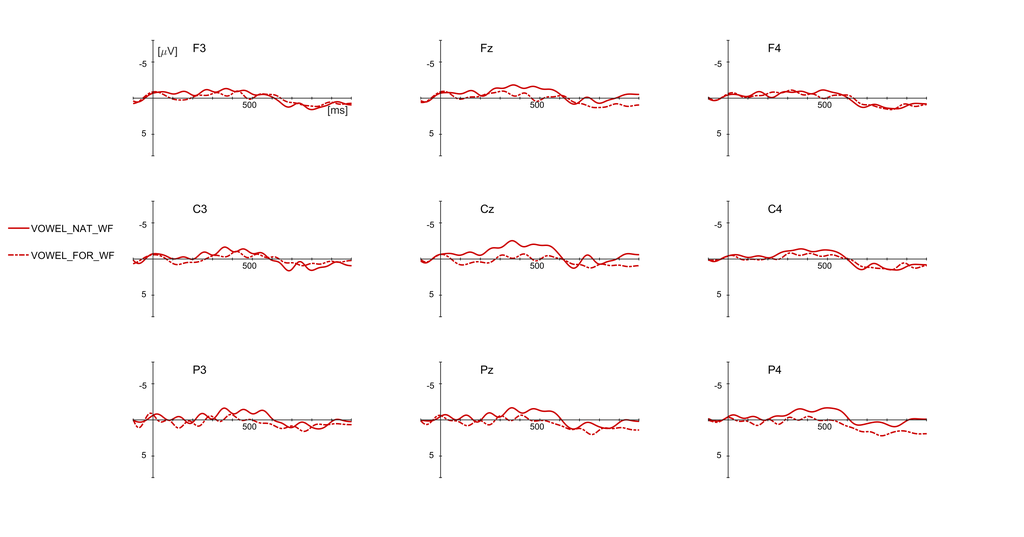

### Hypothesis 5

Sentences with grammatical errors will elicit reduced brain responses (N400, P600) in foreign-accented speech in comparison to native-accented speech.

**300-500 ms** The hypothesis was not confirmed.

**500-900 ms** The hypothesis was not confirmed.

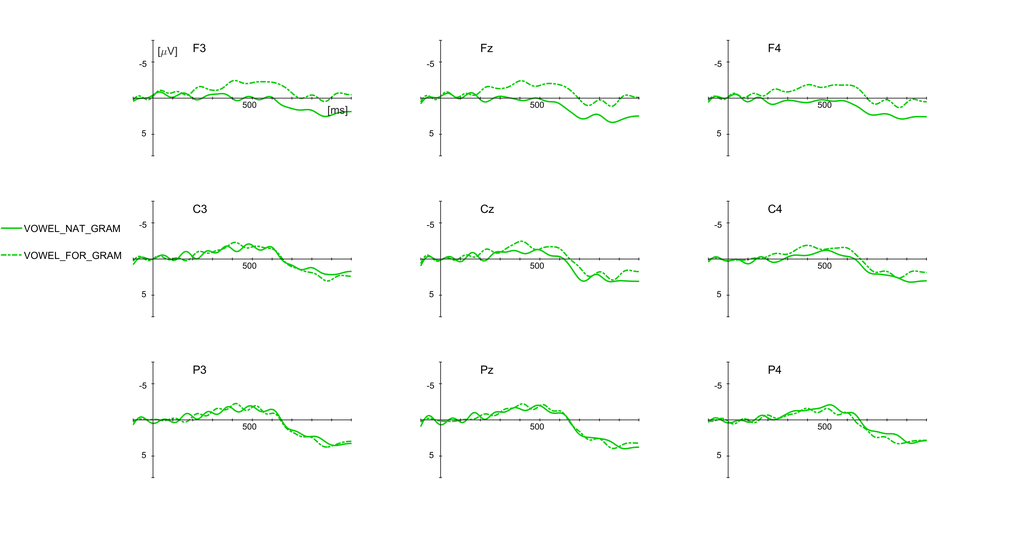

### Hypothesis 6

Sentences with phonetic errors will elicit reduced brain responses (PMN, N400, P600) in foreign-accented speech in comparison to native-accented speech.

**300-500 ms** The hypothesis was not confirmed.

**500-900 ms** The hypothesis was not confirmed.

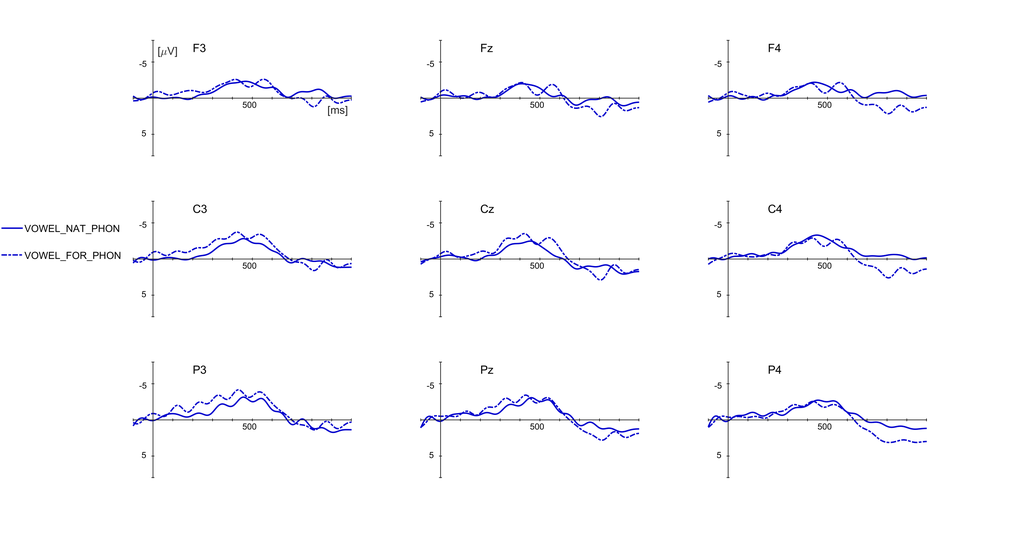